# Analysis proposal

Pierrre

2023-12-13

## Data structure

The flux data is in long format, with each row being the energy flux going to a given consumer. This flux is both presented as a raw value and as the proportion of this flux in the total amount of flux in the bromeliad of interest. Then there are a bunch of columns with traits from the consumers (all from the fwdatabase).  
The crisp CPI column was calculated as the weighted mean of the fuzzy values from Régis and Olivier, with the CP3 values (unbounded interval) is from a literature search I did.  
The stoichiometry values here were generated at random for each row of the data, with no intent on realism. I just generated them so that you can see the analyses I have in mind

```r
dplyr::glimpse(fluxes_long_percons)
```

```
## Rows: 12,298
## Columns: 32
## $ site                  <chr> "CABO", "CABO", "CABO", "CABO", "CABO", "CABO", …
## $ bromeliad_id          <chr> "12151", "12151", "12151", "12151", "12151", "12…
## $ consumer              <chr> "Coleoptera.28", "Coleoptera.30", "Diptera.113",…
## $ flux_raw              <dbl> 9.600550e-01, 7.627321e-01, 1.674131e-01, 7.3056…
## $ flux_prop             <dbl> 1.870389e-01, 1.485963e-01, 3.261560e-02, 1.4232…
## $ cons_ord              <chr> "Coleoptera", "Coleoptera", "Diptera", "Diptera"…
## $ cons_subord           <chr> "Polyphaga", "Polyphaga", "Nematocera", "Nematoc…
## $ cons_family           <chr> "Scirtidae", "Scirtidae", "Culicidae", "Ceratopo…
## $ cons_subfamily        <chr> NA, NA, "Culicinae", "Forcipomyiinae", "Chironom…
## $ cons_genus            <chr> NA, NA, "Culex", "Forcipomyia", "Polypedilum", "…
## $ cons_CP1              <int> 0, 0, 3, 3, 3, 3, 3, 0, 0, NA, NA, 0, 3, 3, 3, 3…
## $ cons_CP2              <int> 1, 1, 0, 1, 1, 1, 1, 0, 0, NA, NA, 1, 0, 1, 1, 1…
## $ cons_CP3              <int> 3, 3, 0, 0, 0, 0, 0, 3, 3, NA, NA, 3, 0, 0, 0, 0…
```

[output cut: 19 more lines]

There is a second data frame that I will do analysis on, one in which each row represents metric summarised at the bromeliad level. Here I will just show for CABO because the distances take a while to compute. We now have the Gini index (bounded between 0 (perfect equality) and 1 (perfect inequality), measuring the inequality in energy fluxes going to consumers, the total amount of energy flowing within the bromeliad, and the average euclidean distance between detritivore stoichiometries (using the triangle formula in a 3D CNP space), which represents how dissimilar these detritivores are in their stoichiometries. The Gini index reflects evenness of energy use by consumer community and energetic overdominance. High inequality is associated with low biodiversity and stability of the system (Potapov 2019)

```r
dplyr::glimpse(fluxes_long_perbrom_CABO)
```

```
## Rows: 10
## Columns: 6
## $ site         <chr> "CABO", "CABO", "CABO", "CABO", "CABO", "CABO", "CABO", "…
## $ bromeliad_id <chr> "12151", "12156", "12161", "12166", "12171", "12176", "12…
## $ gini         <dbl> 0.5388423, 0.7342238, 0.7362310, 0.5645793, 0.6773973, 0.…
## $ totalflow_Jy <dbl> 4.7122419, 2.9988990, 3.9750172, 1.6948711, 1.6767215, 1.…
## $ predflow_Jy  <dbl> 2.2385036, 2.3677528, 1.5737512, 0.3426661, 0.4703478, 0.…
## $ detr_dist    <dbl> 0.1212884, 0.1302893, 0.1443709, 0.1512500, 0.1648265, 0.…
```

## A few plots to start

Here are three plots of energy flux within the bromeliads, based on different values of the Gini index. The idea is that here the Gini index give us a hint on the number of channels in the web, with more channels leading to more equality (i.e. more strong, few weak fluxes), while bromeliads with little or no channel structre will be highly imbalanced.

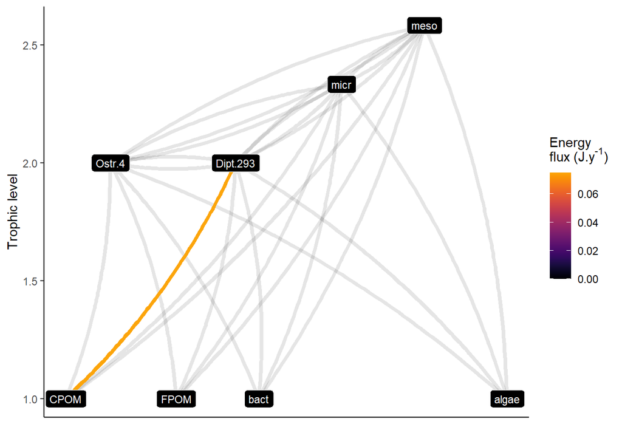

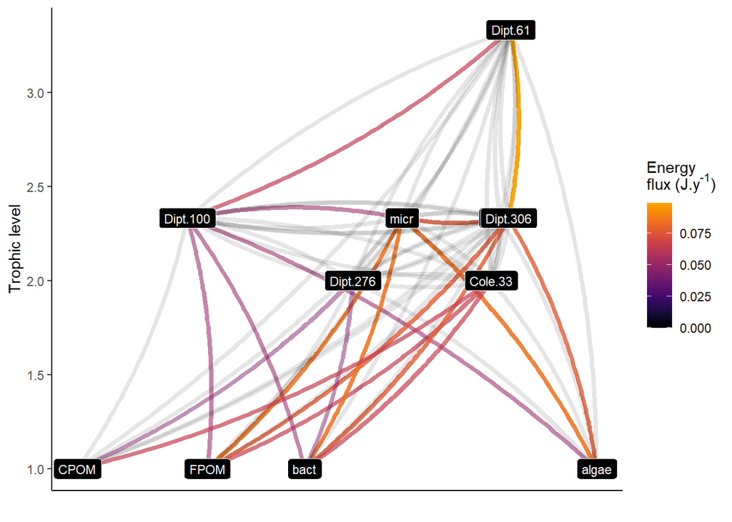

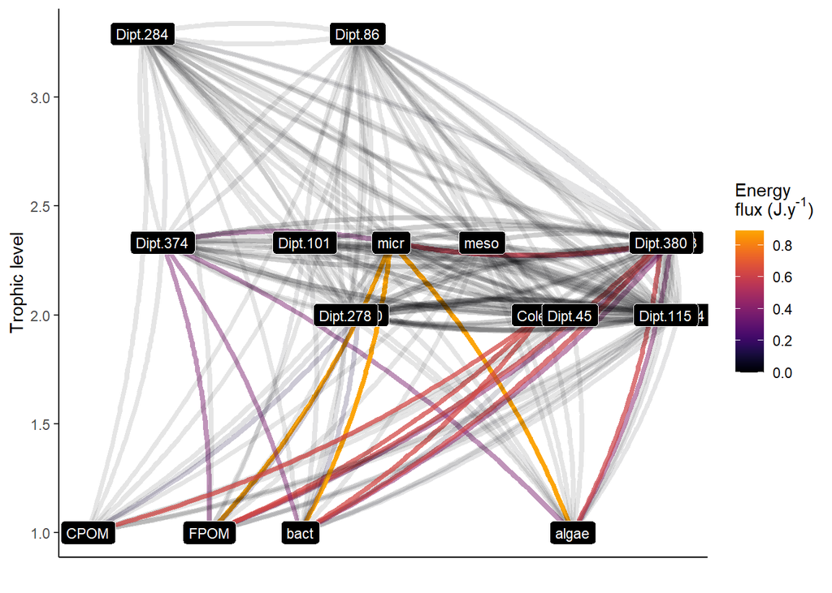

## Hypothesis 1 - Because of a faster growth and turnover rate, consumers with a low CPI and high P content will attract more energy flux than organisms with a slower growth.

Relation between P and CPI We first need to prove our assumption that there is a link between CPI and P content, i.e. a test of the Growth Rate Hypothesis.

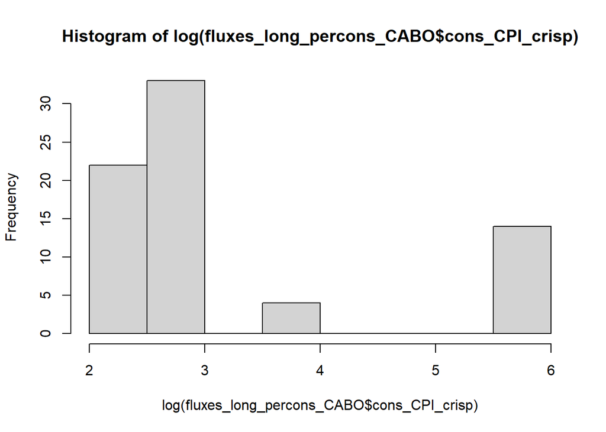

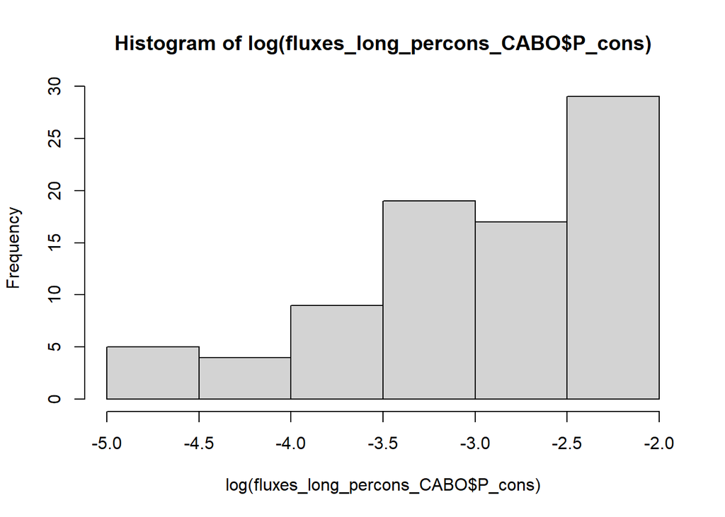

```
## Summary of Posterior Distribution
##
## Parameter   | Median |        95% CI |     pd |          ROPE | % in ROPE |  Rhat |      ESS
## --------------------------------------------------------------------------------------------
## (Intercept) |   2.24 | [ 0.93, 3.57] | 99.95% | [-0.01, 0.01] |        0% | 1.000 | 10162.00
## logP_cons   |  -0.33 | [-0.74, 0.08] | 94.50% | [-0.01, 0.01] |     1.05% | 1.000 | 10526.00
```

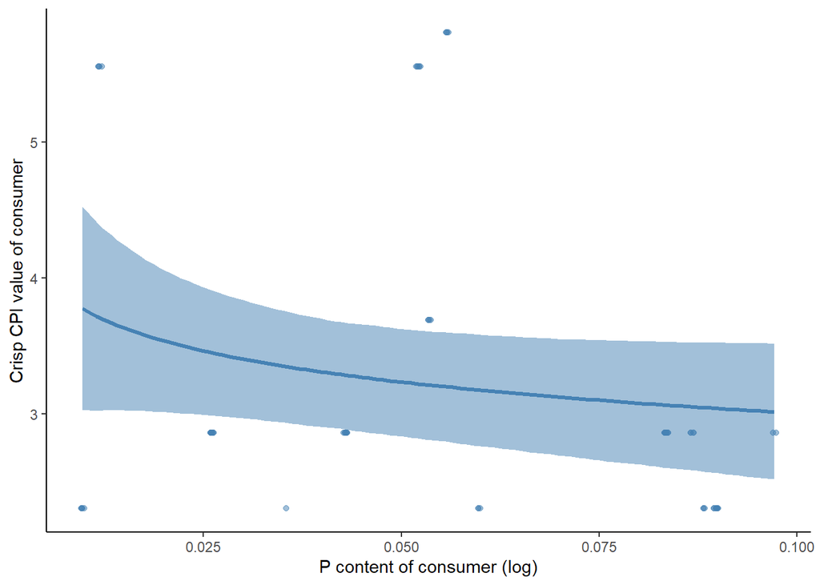

Then, we can go on and see if a higher CPI means lower energy flow NB we are doing this in relative terms because we wouldn’t want bromeliads with higher biomasses (thus more energy to flow) to artificially drive the pattern.

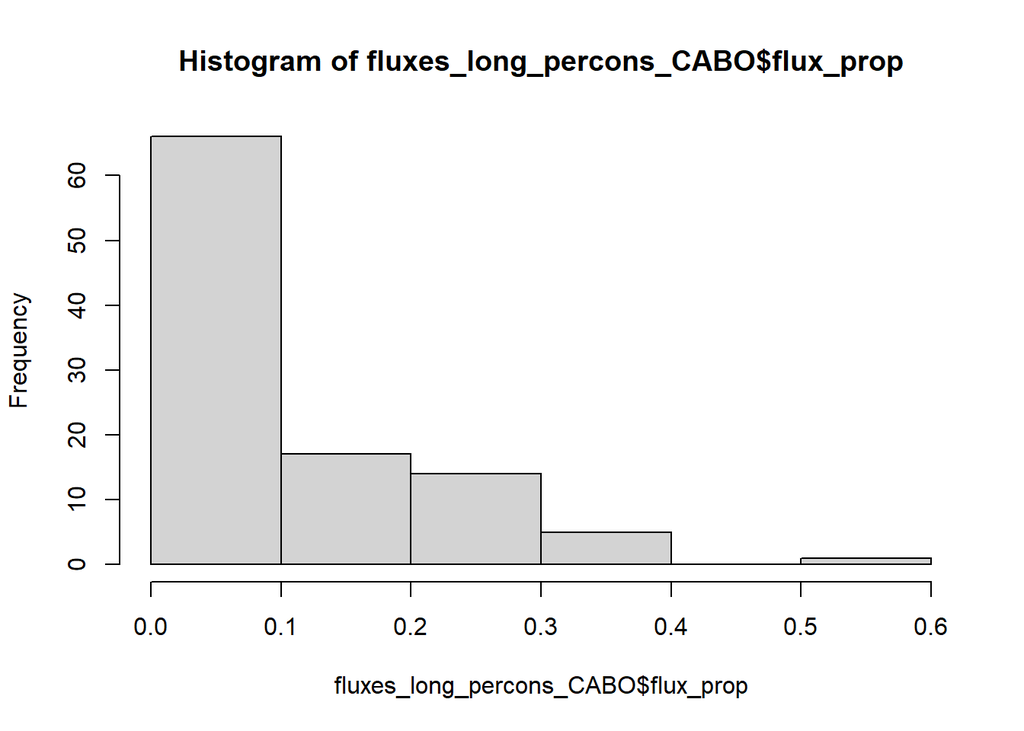

```
## Summary of Posterior Distribution
##
## Parameter         | Median |         95% CI |     pd |          ROPE | % in ROPE |  Rhat |      ESS
## ---------------------------------------------------------------------------------------------------
## (Intercept)       |  -3.34 | [-4.20, -2.45] |   100% | [-0.01, 0.01] |        0% | 1.000 | 11748.00
## logcons_CPI_crisp |   0.16 | [-0.08,  0.40] | 91.09% | [-0.01, 0.01] |     2.87% | 1.000 | 13405.00
```

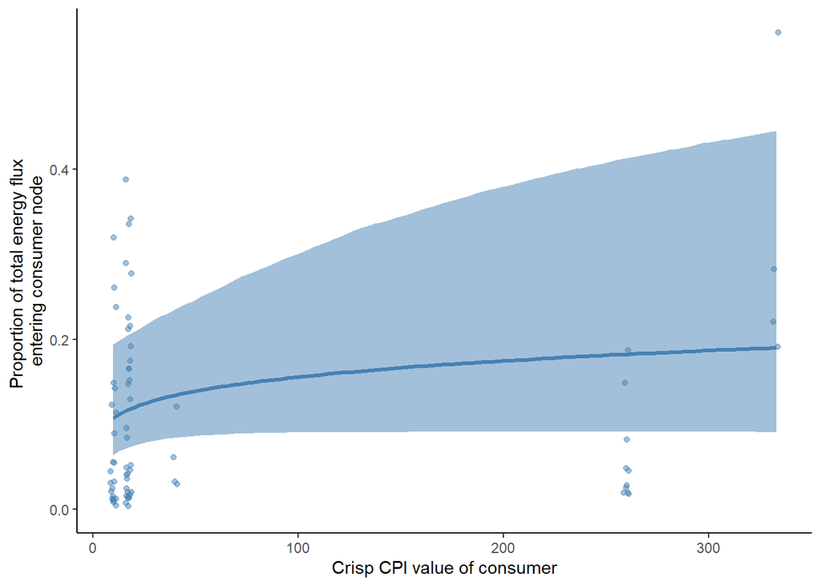

## Hypothesis 2 - Because organisms make feeding decisions based on their stoichiometry and that of their prey, more stoichiometric dissimilarity of consumers in a food web generates more energy channels.

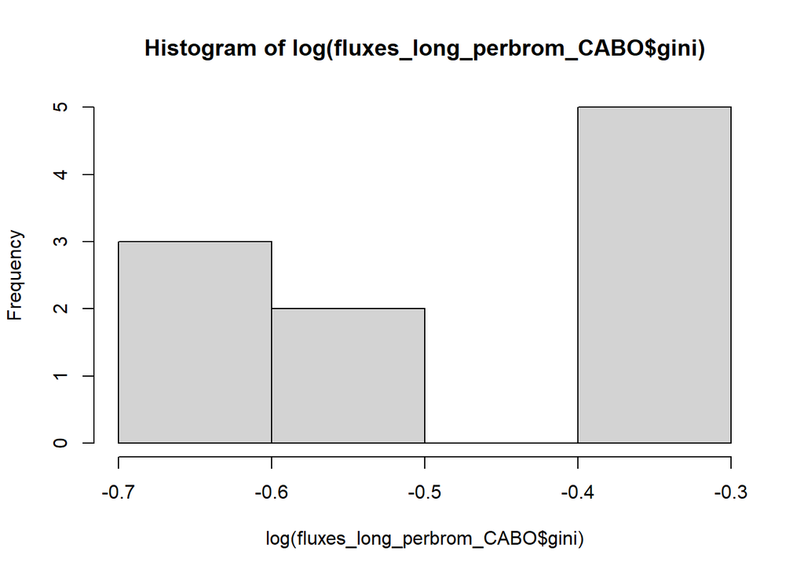

```
## Summary of Posterior Distribution
##
## Parameter    | Median |        95% CI |     pd |          ROPE | % in ROPE |  Rhat |     ESS
## --------------------------------------------------------------------------------------------
## (Intercept)  |  -1.24 | [-3.04, 0.46] | 93.34% | [-0.01, 0.01] |     0.32% | 1.001 | 4964.00
## logdetr_dist |  -0.39 | [-1.32, 0.48] | 83.43% | [-0.01, 0.01] |     1.26% | 1.001 | 4988.00
```

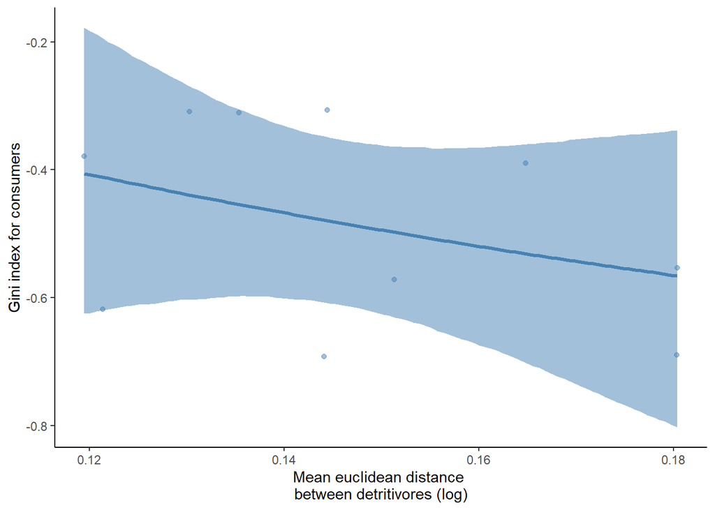

Here we have no association between the channel structure and the stoichiometric dissimilarity of detritivores. This suggests that stoichiometry may not underly channel structures, potentially because phenotypic traits (e.g. different kinds of predator defense or different usage of the environment) could allow organisms with similar stoichiometries to coexist.

# Hypothesis 3 - Stoichiometric dissimilarity and productivity of food webs have a unimodal relationship, because a low dissimilarity (i.e. few channels) and a high dissimilarity (i.e. many, little connected channels) will not allow an efficient transfer of energy towards higher trophic levels.

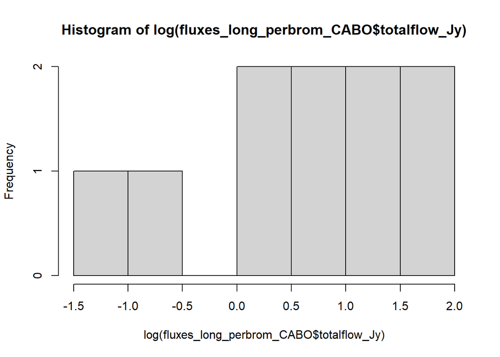

```
## Summary of Posterior Distribution
##
## Parameter                  | Median |         95% CI |     pd |          ROPE | % in ROPE |  Rhat |     ESS
## -----------------------------------------------------------------------------------------------------------
## (Intercept)                |   0.53 | [ 0.15,  0.91] | 99.17% | [-0.01, 0.01] |        0% | 1.000 | 7295.00
## polylogdetr_distdegreeEQ21 |  -2.17 | [-3.44, -0.91] | 99.71% | [-0.01, 0.01] |        0% | 1.001 | 6849.00
## polylogdetr_distdegreeEQ22 |  -1.38 | [-2.60, -0.16] | 98.32% | [-0.01, 0.01] |        0% | 1.000 | 7605.00
```

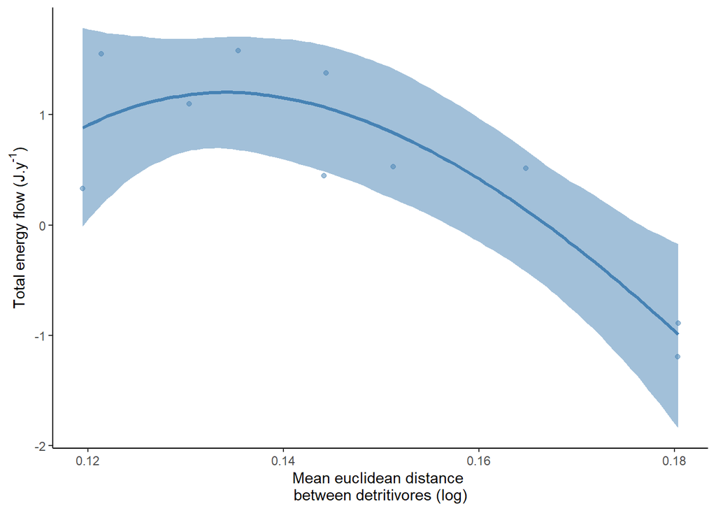

Here can see that the total energy flow in a bromeliad follows a unimodal relationship with the stoichiometric dissimilarity of detritivores. This suggest that more channels, hence a more even parsing of resource use can sustain a more diverse community.

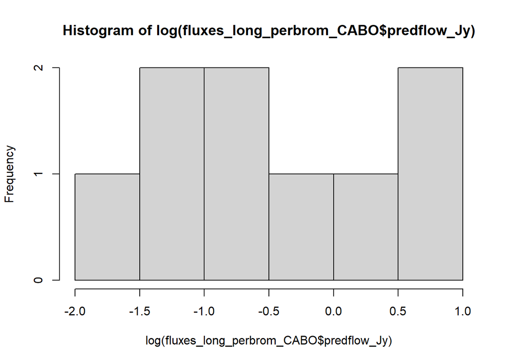

[output not shown]

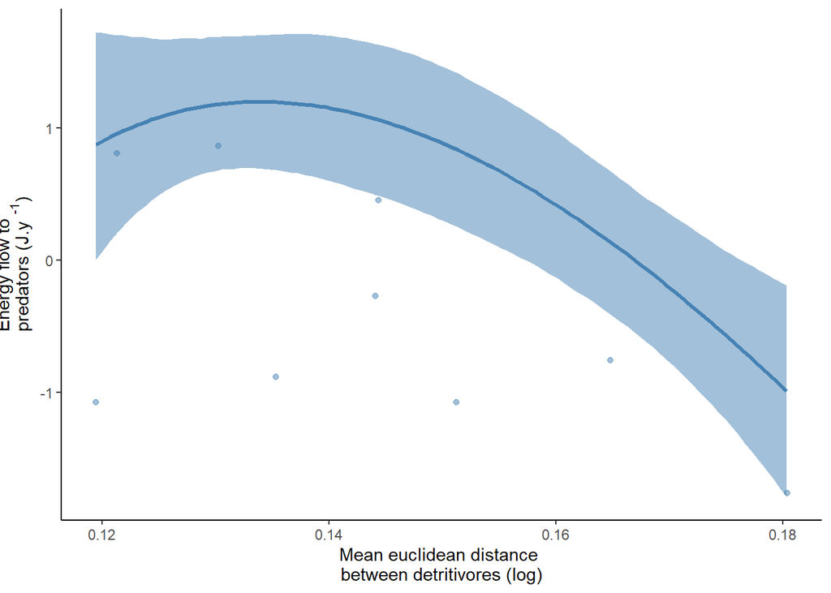